# Assignment 2

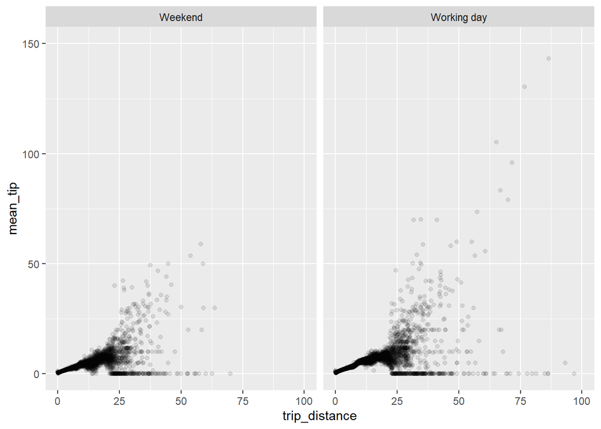

```r
week2.tidy %>%
  group_by(trip_distance, pickupday_type) %>%
  summarise(mean_tip = mean(tip_amount)) %>%
    ggplot(aes(x=trip_distance, y=mean_tip)) + geom_point(alpha=0.1) + xlim(0,100) + ylim(0, 150) + facet_wrap(~pickupday_type)
```

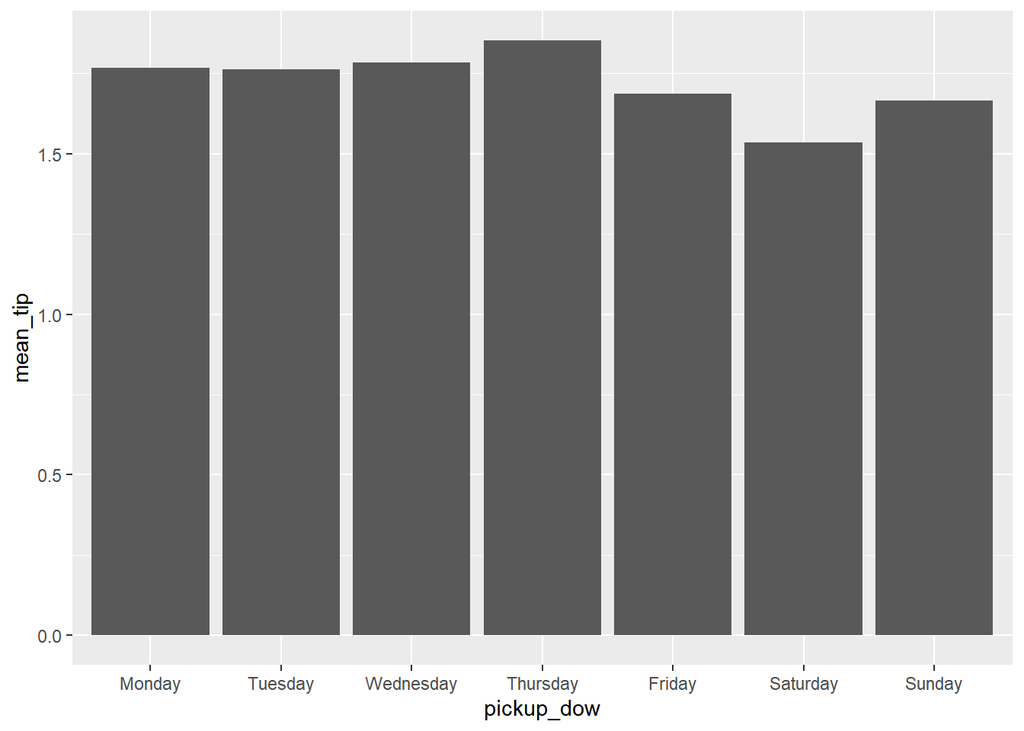

```r
week2.tidy %>%
  group_by(pickup_dow) %>%
  summarise(mean_tip = mean(tip_amount)) %>%
  ggplot(aes(x=pickup_dow, y=mean_tip)) + geom_bar(stat='identity')
```

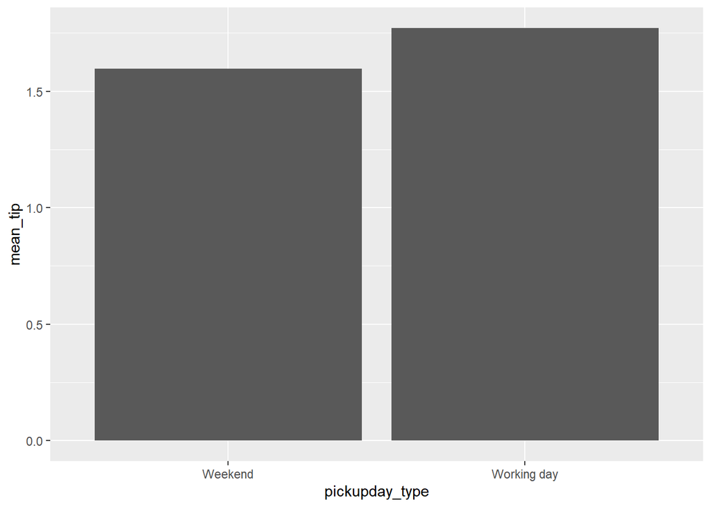

```r
week2.tidy %>%
  group_by(pickupday_type) %>%
  summarise(mean_tip = mean(tip_amount)) %>%
  ggplot(aes(x=pickupday_type, y=mean_tip)) + geom_bar(stat='identity')
```

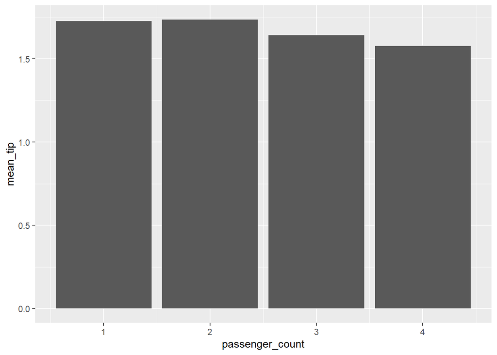

```r
week2.tidy %>%
  group_by(passenger_count) %>%
  summarise(mean_tip = mean(tip_amount)) %>%
  ggplot(aes(x=passenger_count, y=mean_tip)) + geom_bar(stat='identity')
```

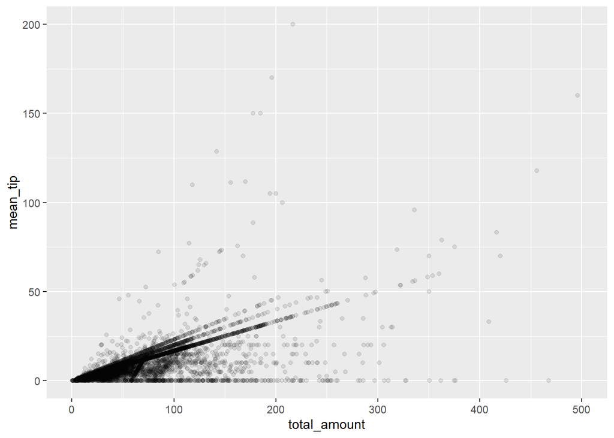

```r
week2.tidy %>%
  group_by(total_amount) %>%
  summarise(mean_tip = mean(tip_amount)) %>%
  ggplot(aes(x=total_amount, y=mean_tip)) + geom_point(alpha=0.1) + xlim(0,500) + ylim(0, 200)
```

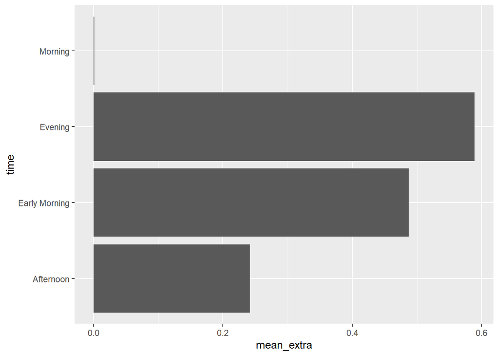

```r
week2.tidy %>%
  group_by(time) %>%
  summarise(mean_extra = mean(extra)) %>%
  ggplot(aes(x=mean_extra, y=time)) + geom_bar(stat='identity')
```

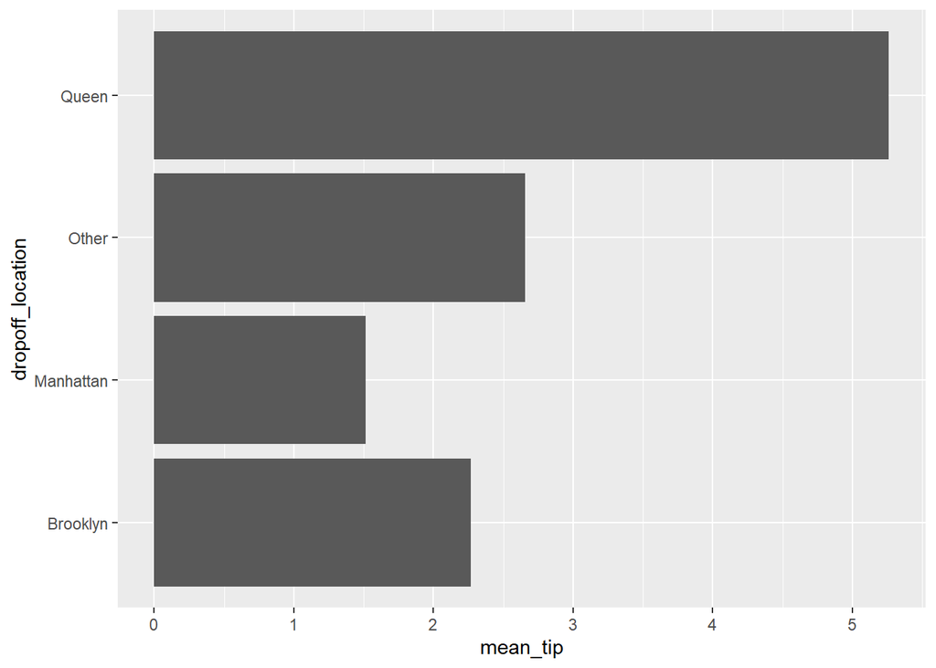

```r
week2.tidy %>%
  group_by(dropoff_location) %>%
  summarise(mean_tip = mean(tip_amount)) %>%
  ggplot(aes(x=mean_tip, y=dropoff_location)) + geom_bar(stat='identity')
```

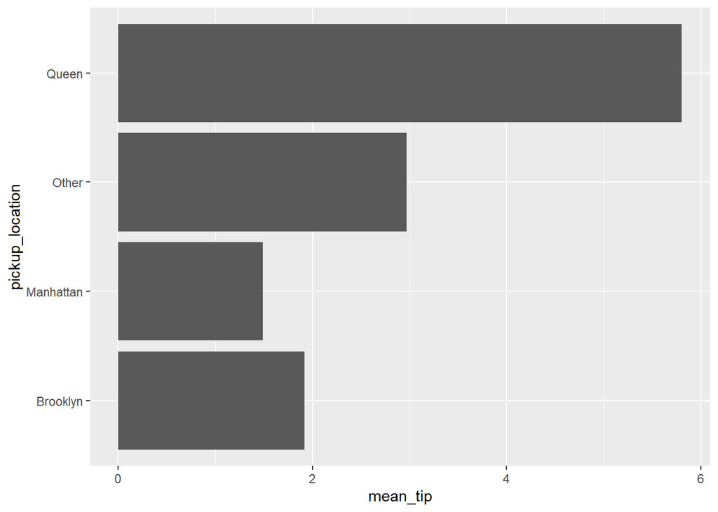

```r
week2.tidy %>%
  group_by(pickup_location) %>%
  summarise(mean_tip = mean(tip_amount)) %>%
  ggplot(aes(x=mean_tip, y=pickup_location)) + geom_bar(stat='identity')
```

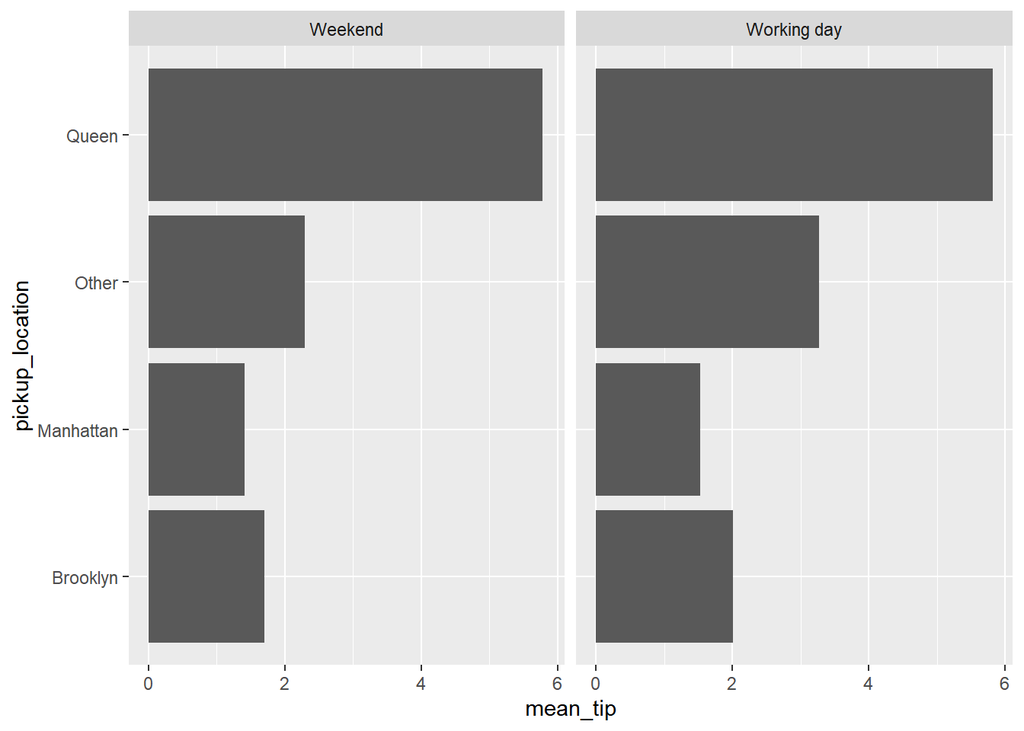

```r
week2.tidy %>%
  group_by(pickup_location, pickupday_type) %>%
  summarise(mean_tip = mean(tip_amount)) %>%
  ggplot(aes(x=mean_tip, y=pickup_location)) + geom_bar(stat='identity') + facet_wrap(~pickupday_type)
```

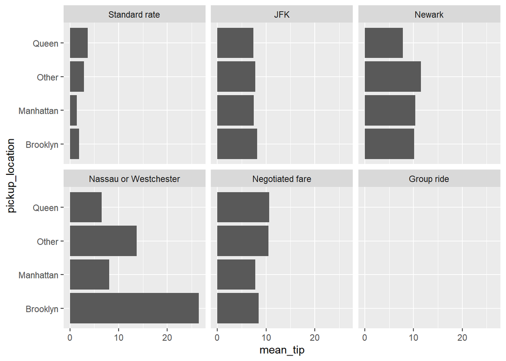

```r
week2.tidy %>%
  group_by(pickup_location, RatecodeID) %>%
  summarise(mean_tip = mean(tip_amount)) %>%
  ggplot(aes(x=mean_tip, y=pickup_location)) + geom_bar(stat='identity') + facet_wrap(~RatecodeID)
```

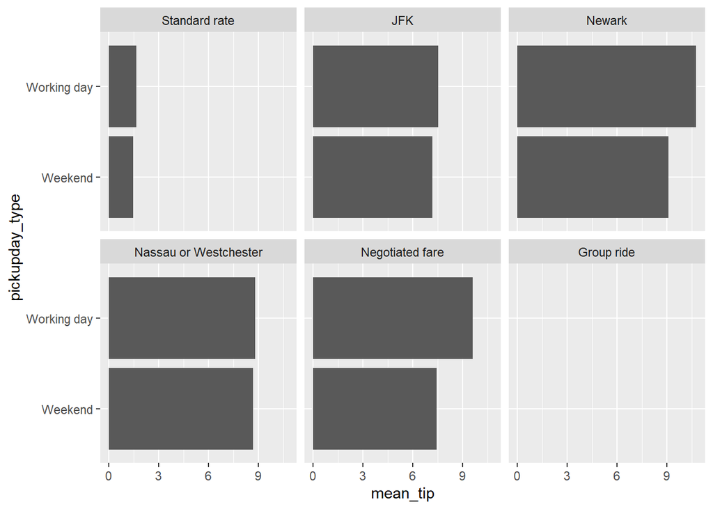

```r
week2.tidy %>%
  group_by(pickupday_type, RatecodeID) %>%
  summarise(mean_tip = mean(tip_amount)) %>%
  ggplot(aes(x=mean_tip, y=pickupday_type)) + geom_bar(stat='identity') + facet_wrap(~RatecodeID)
```

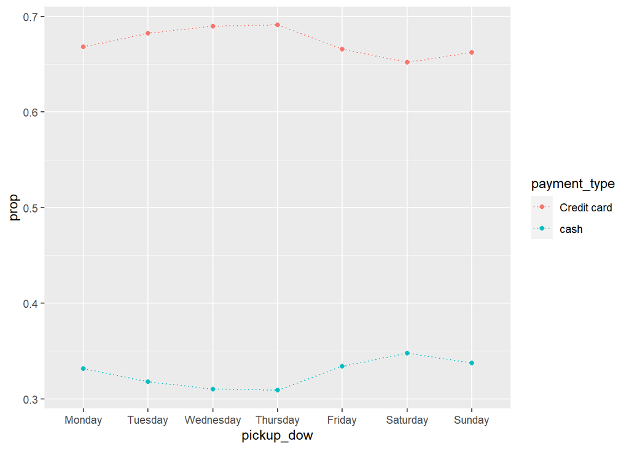

```r
week2.tidy %>%
  filter(payment_type %in% c('Credit card','cash')) %>%
  group_by(pickup_dow,payment_type) %>%
  summarise(n = n()) %>%
  mutate(sum = sum(n), prop = n/sum) %>%
  ggplot(aes(x=pickup_dow, y=prop,color=payment_type, group=payment_type)) + geom_point() + geom_line(linetype='dotted')
```

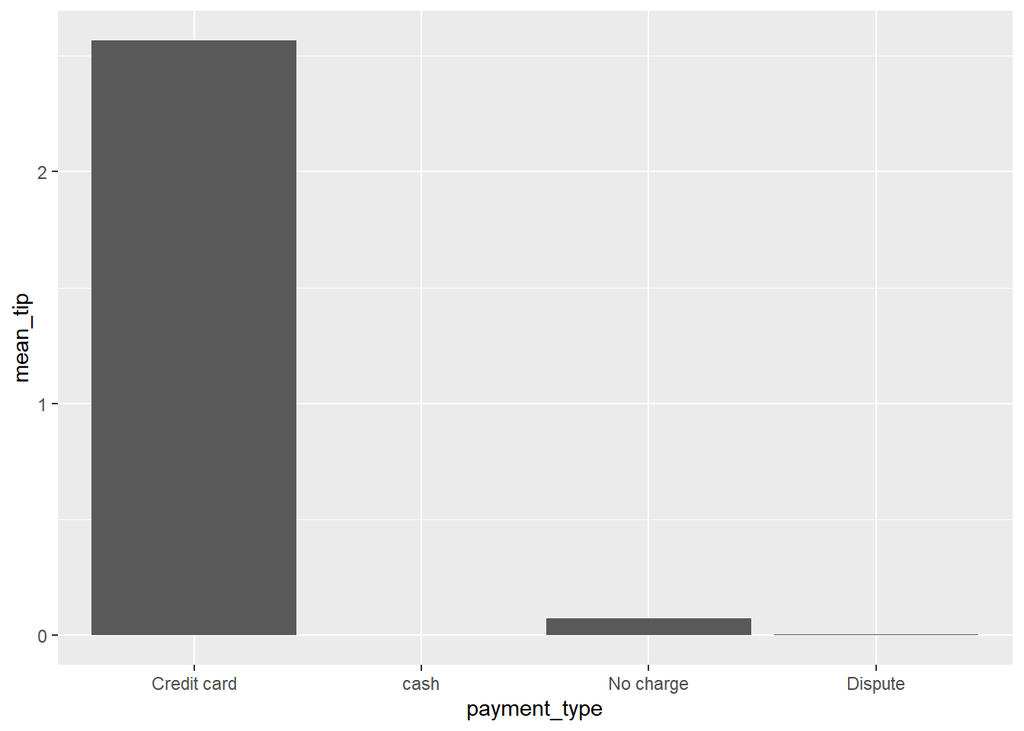

```r
week2.tidy %>%
  group_by(payment_type) %>%
  summarise(mean_tip = mean(tip_amount)) %>%
    ggplot(aes(x=payment_type, y=mean_tip)) + geom_bar(stat='identity')
```

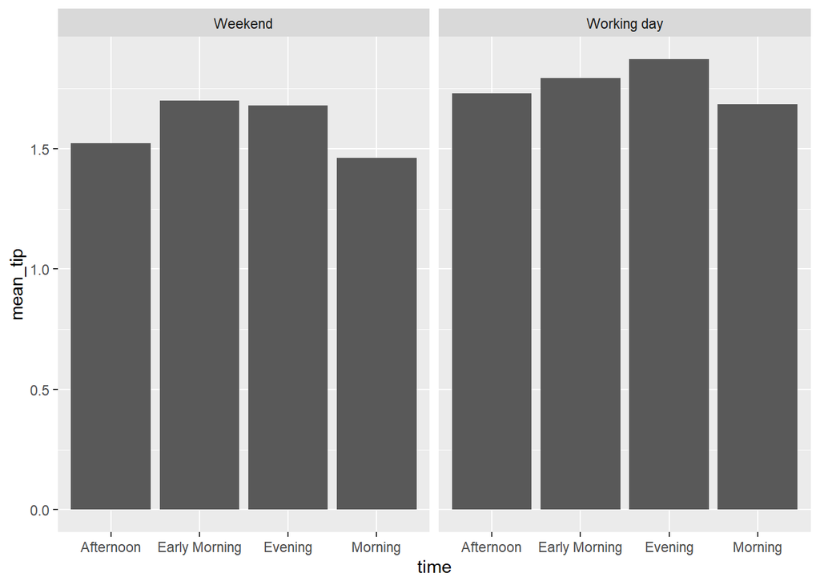

```r
week2.tidy %>%
  group_by(time, pickupday_type) %>%
  summarise(mean_tip=mean(tip_amount)) %>%
  ggplot(aes(x=time, y=mean_tip)) + geom_bar(stat='identity') + facet_wrap(~pickupday_type)
```

```r
# remove more variables
week2.tidy = week2.tidy %>%
  select(-tolls_amount, -dropoff_location, -pickup_dow, -payment_type, -total_amount)
```

```r
# Sampling data because it takes too much time and RAM

set.seed(369)
index = sample(1:nrow(week2.tidy), nrow(week2.tidy)*0.2)
week2.sample = week2.tidy[index,]

mf<-model.frame(tip_amount~., data=week2.sample)
X<-model.matrix(tip_amount~., mf)[,-1]

library(leaps)
```

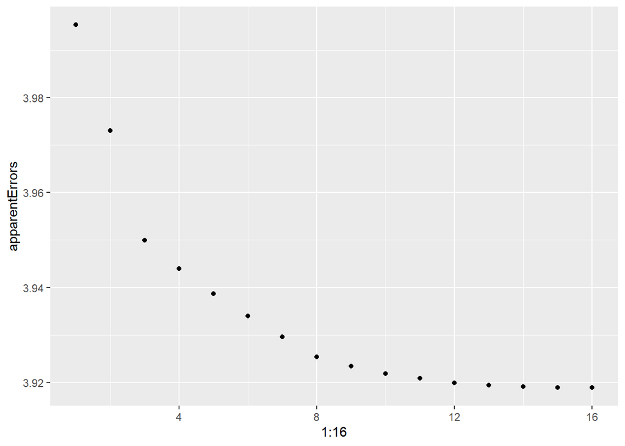

```r
subsets1.reg = regsubsets(X, week2.sample$tip_amount, nvmax = 16, method = "backward")
subsets1.summary = summary(subsets1.reg)
apparentErrors = subsets1.summary$rss / (nrow(week2.sample) - 1:16)
qplot(y = apparentErrors, x= 1:16)
```

```r
allyhat<-function(xtrain, ytrain, xtest,lambdas,nvmax){
  n<-nrow(xtrain)
  yhat<-matrix(nrow=nrow(xtest),ncol=length(lambdas))
  search<-regsubsets(xtrain,ytrain, nvmax=nvmax, method="back")
  summ<-summary(search)
  for(i in 1:length(lambdas)){
    penMSE<- n*log(summ$rss)+lambdas[i]*(1:nvmax)
    best<-which.min(penMSE)  #lowest AIC
    betahat<-coef(search, best) #coefficients
    xinmodel<-cbind(1,xtest)[,summ$which[best,]] #predictors in that model
    yhat[,i]<-xinmodel%*%betahat
  }
  yhat
}

y = week2.sample$tip_amount

n<-nrow(X)
folds<-sample(rep(1:10,length.out=n))
lambdas<-c(2,4,6,8,10,12)
fitted<-matrix(nrow=n,ncol=length(lambdas))
for(k in 1:10){
  train<- (1:n)[folds!=k]
  test<-(1:n)[folds==k]
  fitted[test,]<-allyhat(X[train,],y[train],X[test,],lambdas,nvmax = 16)
}
rbind(lambdas,colMeans((y-fitted)^2))
```

```
##             [,1]     [,2]     [,3]     [,4]      [,5]      [,6]
## lambdas 2.000000 4.000000 6.000000 8.000000 10.000000 12.000000
##         3.951907 3.951907 3.952305 3.952305  3.952305  3.952305
```

```r
colMeans((y-fitted)^2)
```

```
## [1] 3.951907 3.951907 3.952305 3.952305 3.952305 3.952305
```

Due to limited computational resources (my Rstudio could not handle it and it crashed), I have decided to sample the data and fit a linear model without any interaction. Interaction was also not fitted because it required higher computational resources and there wasn’t much difference in average tips for adding interaction like different locations and time or weekends vs weekdays as shown above. Using cost-complex strategy, we have fitted various lambdas and last four lambda give us the same result. The lambda of 2 will be used as we do not want to penalise the model if it gives the same result with higher penalties. Looks like AIC is good enough for this model.

```r
search<-regsubsets(X,y, nvmax=16, method="back")
summ<-summary(search)
penMSE<- nrow(X)*log(summ$rss)+2*(1:16)
best<-which.min(penMSE) #lowest penalisedRSS
betahat<-coef(search, best) #coefficients
xinmodel<-cbind(1,X)[,summ$which[best,]]
yhat2<-xinmodel%*%betahat
betahat
```

```
##                     (Intercept)                 passenger_count
##                      0.20374223                     -0.06143116
##                   trip_distance                   RatecodeIDJFK
##                      0.13370425                      0.67716427
##                RatecodeIDNewark RatecodeIDNassau or Westchester
##                      2.01230135                      0.86359566
##       RatecodeIDNegotiated fare                     fare_amount
##                     -1.25429379                      0.09693716
##                           extra               timeEarly Morning
##                      0.09697920                     -0.13040965
##                     timeEvening                     timeMorning
##                      0.11441157                      0.04599229
##        pickup_locationManhattan            pickup_locationOther
##                     -0.10520610                      0.27248767
##            pickup_locationQueen       pickupday_typeWorking day
##                     -1.43785589                      0.09983914
```

```r
week4.tidy = week4.df %>%
  filter(trip_distance >0) %>%
  filter(RatecodeID <= 6) %>%
  filter(fare_amount >0) %>%
  filter(extra >=0) %>%
  filter(mta_tax >=0) %>%
  filter(tip_amount>=0) %>%
  filter(improvement_surcharge>=0) %>%
  filter(total_amount > 0) %>%
  filter(passenger_count >0 & passenger_count <=4) %>%
  filter(between(pickup_longitude, -75, -70)) %>%
  filter(between(pickup_latitude, 40, 42)) %>%
  mutate(time = case_when(hour(tpep_pickup_datetime) >= 0 & hour(tpep_pickup_datetime) <= 5 ~ "Early Morning",
                          hour(tpep_pickup_datetime) >= 6 & hour(tpep_pickup_datetime) <= 11 ~ "Morning",
                          hour(tpep_pickup_datetime) >= 12 & hour(tpep_pickup_datetime) <= 17 ~ "Afternoon",
                          hour(tpep_pickup_datetime) >= 18 & hour(tpep_pickup_datetime) <= 23 ~ "Evening")) %>%
  mutate(pickup_location = case_when(between(pickup_latitude, 40.7, 40.88) & between(pickup_longitude, -74, -73.91) ~ "Manhattan",
                              between(pickup_latitude, 40.57, 40.7378) & between(pickup_longitude, -74.039, -73.858) ~ "Brooklyn",
                              between(pickup_latitude, 40.63, 40.739) & between(pickup_longitude, -73.96, -73.7) ~ "Queen",
                              TRUE~"Other")) %>%
  mutate(dropoff_location = case_when(between(dropoff_latitude, 40.7, 40.88) & between(dropoff_longitude, -74, -73.91)~ "Manhattan",
                              between(dropoff_latitude, 40.57, 40.7378) & between(dropoff_longitude, -74.039, -73.858) ~ "Brooklyn",
                              between(dropoff_latitude, 40.63, 40.739) & between(dropoff_longitude, -73.96, -73.7) ~ "Queen",
                              TRUE~"Other")) %>%
  mutate(pickup_dow = factor(weekdays(tpep_pickup_datetime), levels=c("Monday", "Tuesday", "Wednesday", "Thursday", "Friday", "Saturday", "Sunday"))) %>%
  mutate(payment_type = fct_recode(factor(payment_type), "Credit card" = "1", "cash" = "2", "No charge" = "3", "Dispute" = "4", "Unknown" = "5", "Voided trip" = "6")) %>%
  mutate(RatecodeID = fct_recode(factor(RatecodeID), "Standard rate" = "1", "JFK" = "2", "Newark" = "3", "Nassau or Westchester" = "4", "Negotiated fare" = "5", "Group ride" = "6")) %>%
  mutate(pickupday_type = case_when(pickup_dow %in% c("Monday", "Tuesday", "Wednesday", "Thursday", "Friday") ~ "Working day",
                             pickup_dow %in% c("Saturday", "Sunday") ~ "Weekend")) %>%
  select(tip_amount, passenger_count, trip_distance, RatecodeID, payment_type, fare_amount, extra, tolls_amount, total_amount, time, pickup_location, dropoff_location, pickup_dow, pickupday_type)
week4.tidy = week4.tidy %>%
  select(-tolls_amount, -dropoff_location, -pickup_dow, -payment_type, -total_amount)
```

Week 4 data have been cleaned the same way as week 2 to remove any meaningless columns and outliers that do not make sense. The variables need to be consistent with week 2 training data to test the model with week 4 test data.

```r
set.seed(369)
index2 = sample(1:nrow(week4.tidy), nrow(week4.tidy)*0.2)
week4.sample = week4.tidy[index2,]

mf<-model.frame(tip_amount~., data=week4.sample)
X2<-model.matrix(tip_amount~., mf)[,summ$which[best,]]

fitted = X2 %*% betahat

MSPEsample = sum((week4.sample$tip_amount - fitted)^2) / length(fitted)
MSPEsample
```

```
## [1] 4.201155
```

```r
prediction.test = week4.sample %>%
  filter(tip_amount == 1.72) %>%
  select(-tip_amount) %>%
  slice(1)

prediction.test
```

```
## # A tibble: 1 x 8
##   passenger_count trip_distance RatecodeID    fare_amount extra time
##             <dbl>         <dbl> <fct>               <dbl> <dbl> <chr>
## 1               1          1.67 Standard rate          13     0 Morning
## # ... with 2 more variables: pickup_location <chr>, pickupday_type <chr>
```

```r
# Using the beta calculated,and a row of values with tip of 1.72
prediction = as.numeric(betahat[1] + betahat[2] *prediction.test[1] + betahat[3] * prediction.test[2]  + prediction.test[4]*betahat[8] + betahat[12] + betahat[13] + betahat[16])
prediction
```

```
## [1] 1.666406
```

```r
apparent_error = sum((week2.sample$tip_amount - yhat2))/ (nrow(week2.sample) - length(betahat))
apparent_error
```

```
## [1] -1.786346e-14
```

```r
summary(week2.sample$tip_amount)
```

```
##    Min. 1st Qu.  Median    Mean 3rd Qu.    Max.
##   0.000   0.000   1.350   1.719   2.260 520.380
```

There was also a problem with specifying borough as locations had to be estimated using latitude and longitude and unless the location is square shaped, it had to be a rough estimation. It was also beyond of the course, so location had to be roughly estimated.

Face validity of the model: The whole point of the assignment was to construct a model that predicts the amount of a tip and we have. On the surface level, the model predicts the amount of tip but it only predicts tip that is paid by credit cards. From the plot where it shows proportion of the payment type depending on the day, we can clearly observe that on average there is 65% proportion on paying by credit card. This means that on average, 35% is neglected because it was never recorded in the dataset and that is a good amount of cash uses. Therefore, the model only predicts tips paid by credit cards and it misses out on the 35% of the cash tips so the model does not accurately predict the amount of tip. To conclude, the model does not predict properly on tips due to the missing data.

Given above information, the model’s predictability has space for improvement and once the lock down is finished, I could use the school computer to try the 2 way interaction model and see how much MSPE have improved or worsened. However, for now we will leave it.